# Epidemic simulation and inference from the simulated data

Lucy M Li

2017-06-16

```r
library(EpiGenR)
library(ape)
library(ggplot2)
library(grid)
library(gridExtra)
fig.counter <- list()
knitr::opts_chunk$set(warning=FALSE, error=TRUE, message=FALSE, echo=TRUE)
```

1. Simulate epidemic data
2. Convert line list data and pathogen phylogeny into list objects
3. Construct input objects for inference
4. Call the EpiGenMCMC program to estimate parameters

## 1. Simulate epidemic data

In the example here, I simulate an epidemic according to a stochastic SIR model, which is a state space model with 3 state variables: Susceptible, Infected, and Removed. Two events can occur to change the state variable values: infection and recovery. Simulation takes in discrete steps indexed by $t$, where each step size is $dt$. During each small time interval $[(t-1)\cdot dt, t\cdot dt]$, the number of recovery events given $I_t$ infected individuals and a recovery rate of $\gamma$ is approximate binomial $\textrm{recoveries}_t\sim Bin(I_t,\gamma \Delta t)$. Assuming all onward transmissions occur at recovery, the number of infection events during a time interval $[(t-1)\cdot dt, t\cdot dt]$ follows the offspring distribution which I model using the negative binomial $\textrm{infections}_t \sim NBin(\textrm{recoveries}_t\times R_t,\textrm{recoveries}_t \times k)$.

we assume an S->I->R model of disease progression in which susceptible individuals become infected and capable of infecting others, and later recover and stop being infectious. The time to recovery is exponentially distributed with rate $\gamma$. Upon recovery, an infector infects $b_{0}$ number of individuals. The number of onward infections, i.e. `offspring’, caused by each infected individual is a random variable drawn from a negative binomial offspring distribution $B \sim NBin(R, k)$ with mean $R=\frac{\sum_{i=0}^{N-1}b_i}{N}$, dispersion parameter $k$, and variance $\sigma^2 = R(1+\frac{R}{k})$. The mean of the offspring distribution is the reproductive number of the infectious disease, and is related to the basic reproduction number $R_0$ via the proportion of susceptible individuals in the population: $R=R_0\frac{S}{N}$. The parameter $k$ determines the level of overdispersion in the population. At smaller values of $k$, most individuals do not cause any further infections while a few contribute to most of the transmission events.

Setting $N=$ 5,000, $R_0=$ 2, $k=$ 0.5, and duration of infectiousness $\frac{1}{\gamma}=$ 5 days, we can simulate the outbreak using

```r
seed.num <- 1010113
set.seed(seed.num)
sim.outbreak <- simulate_sir(params, dt, total_dt, min_epi_size, max_attempts, TRUE)
```

The offspring distribution of the simulated epidemic follows a negative binomial distribution

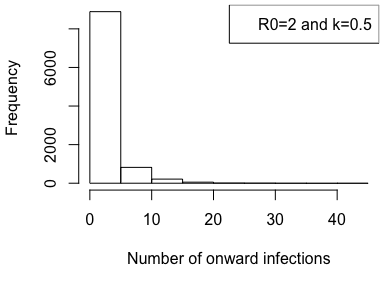

```r
par(mar=c(5.1, 4.1, 0.25, 0.25))
offspring <- rnbinom(10000, mu=R0, size=k)
hist(offspring, xlab="Number of onward infections", main="")
legend("topright", legend=paste0("R0=", round(R0, 2), " and k=", k))
```

The final epidemic size was 4,052.

## Simulated epidemic trajectories

The epidemic trajectories denoted by the incidence and prevalence curves are shown in the Figure 2 below. Assuming that infectious individuals are reported at the time of recovery, the incidence curve shows the daily number of reported cases.

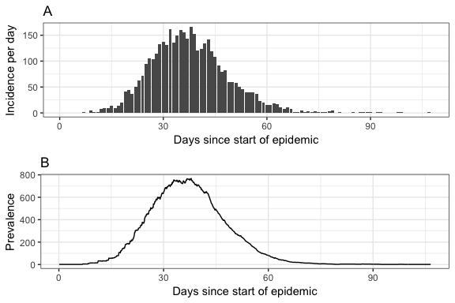

Figure 2. The daily incidence (A) and prevalence (B) of the simulated epidemic.

```r
P1 <- ggplot(data.frame(time_series_from_line_list(sim.outbreak))) + theme_bw() +
  geom_bar(aes(x=time, y=incidence), stat="identity") +
  xlab("Days since start of epidemic") +
  ylab("Incidence per day") + ggtitle("A")
P2 <- ggplot(data.frame(x=(1:sim.outbreak$total_dt)*dt, Prevalence=sim.outbreak$prevalence)) +
  theme_bw() + geom_line(aes(x=x, y=Prevalence)) +
  xlab("Days since start of epidemic") + ggtitle("B")
grid.arrange(P1, P2, ncol=1)
```

# 2. Convert line list data and pathogen phylogeny into list objects

## Transmission Tree

```r
sim.transmission.tree <- as.data.frame(get_transmission_tree(sim.outbreak$infected))
sim.transmission.tree$from <- as.factor(sim.transmission.tree$from)
sim.transmission.tree$to <- as.factor(sim.transmission.tree$to)
fig.counter.sim.graph <- fig.counter
```

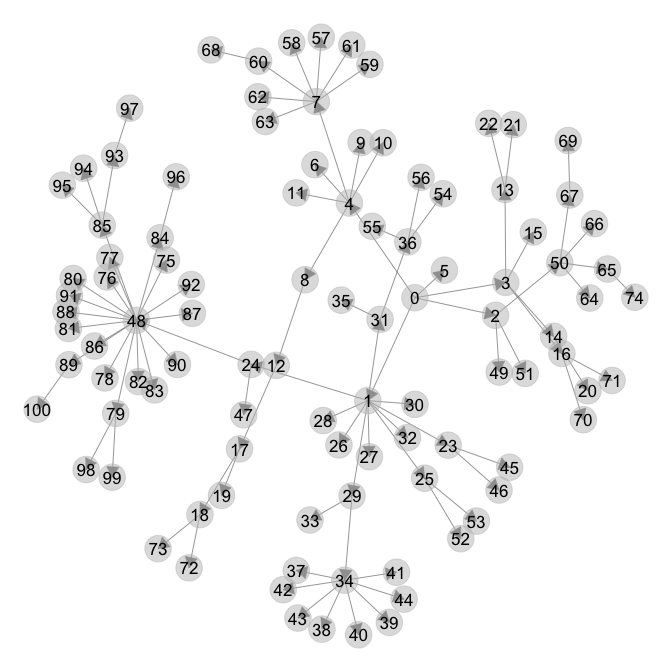

Figure 3. Transmission tree.

## Phylogeny

```r
tree <- get_phylo(sim.outbreak$infected)
```

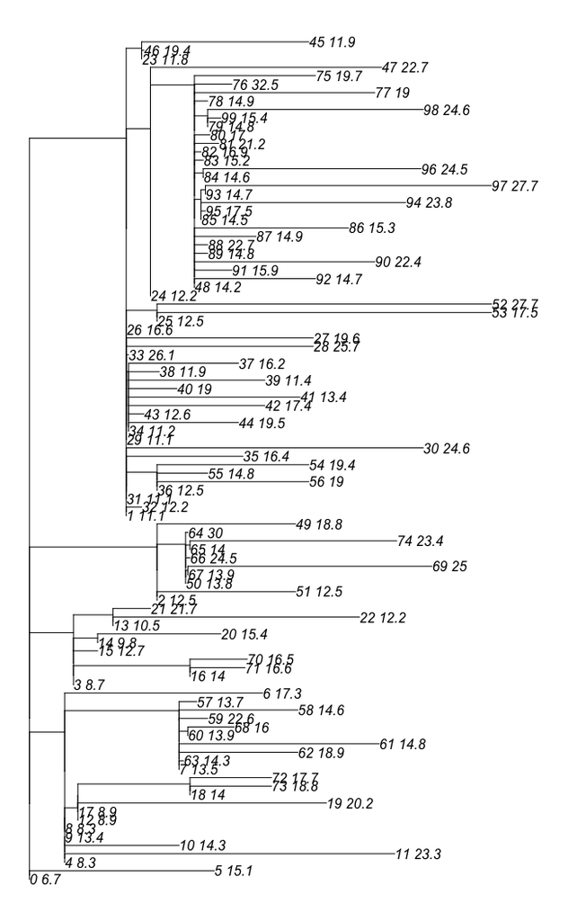

Figure 4. Phylogeny of the first 100 individuals to be infected during the simulated epidemic, out of a total of $N=$4052.

```r
par(mar=c(0.5, 0.5, 0.5, 0.5))
not.sampled.tips <- 101:length(tree$tip.label)
subtree <- drop.tip(tree, not.sampled.tips)
plot(subtree)
```

## Producing time-series data from simulation

```r
sampling.prob <- 0.01
data.dt <- 1
set.seed(seed.num)
sampled.sim.outbreak <- downsample(sim.outbreak, strategy="proportional", prob=sampling.prob)
epi_data <- time_series_from_line_list(sampled.sim.outbreak, step_size=data.dt)
head(epi_data)
```

```
##      time incidence
## [1,]    1         0
## [2,]    2         0
## [3,]    3         0
## [4,]    4         0
## [5,]    5         0
## [6,]    6         0
```

And the phylogeny of the randomly sampled individuals is given in Figure 5.

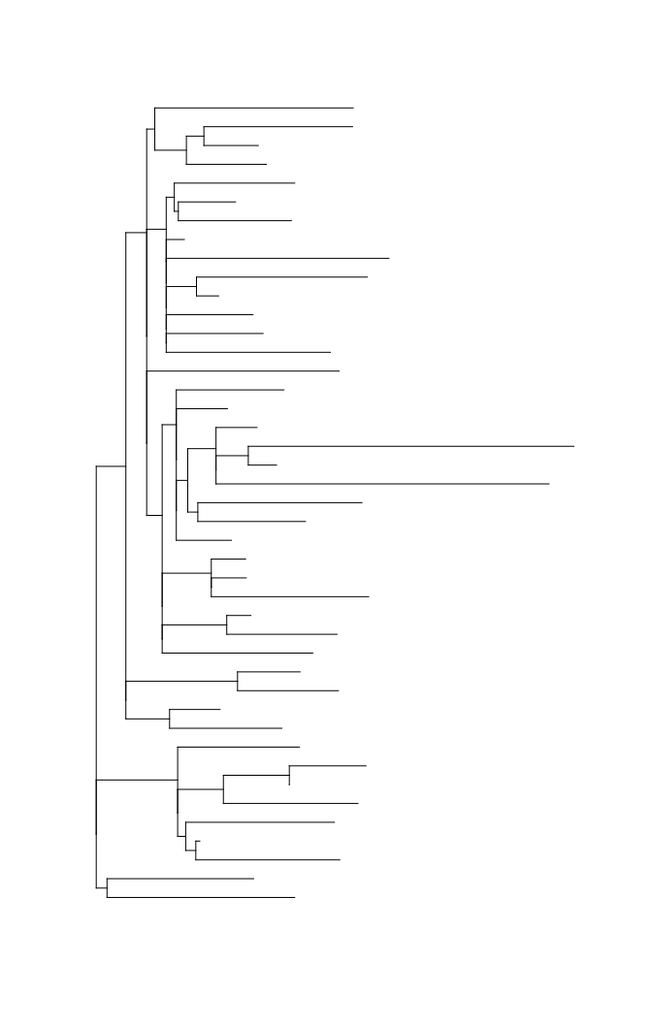

Figure 5. Phylogeny of 43 randomly sampled individuals. This is a subtree of the full phylogeny of N=4052 individuals.

```r
subtree <- drop.tip(reorder.phylo(tree, "postorder"), which(!(1:length(tree$tip.label) %in% sampled.sim.outbreak$sampled_individuals)))
plot(subtree, show.tip.label=FALSE)
```

```r
gen_data <- EpiGenR::coal.intervals.in.discrete.time(EpiGenR::coalescent.intervals.datedPhylo(subtree), data.dt)
```

# 3. Construct input objects for inference

## Create input files for EpiGenMCMC program

```r
param_list <- create_params_list(
  param_names=c("R0", "k", "rateI2R", "N", "S", "reporting", "time_before_data"), # All parameter values
  init_param_values=c(R0, k, 1/Tg, N, S, sampling.prob, 10), # Initial parameter values
  params_to_estimate=c("R0", "k", "rateI2R", "reporting"), # Names of parameters to be estimated
  transform=c(NA, NA, "inverse", NA, NA), # The algorithm will estimate the value of the transformed parameter
  prior=c("unif", "unif", "unif", "beta", "unif"), # Prior distribution
  prior_params=list(c(1.0, 100.0), c(1.0, 10000.0), c(1.0, 30.0), c(1.0, 3.0)), # Parameters for the prior distribution
  proposal_params=list(c(0.5, 1.0, 100.0), c(0.1, 0.001, 10), c(1.0, 1.0, 30.0), c(0.05, 0.0, 1.0)),
  # proposal_params: each element of the list includes the standard deviation
  # of proposal distribution, and the range of parameter values to be explored
  optimal_acceptance=0.234,
  lower_acceptance=0.1, upper_acceptance=0.8,
  adapt_every=20,
  max_adapt_times=100
)


mcmc_options <- create_mcmc_options (
  particles=1000, iterations=1000, log_every=1, pfilter_every=20,
  which_likelihood=0, # 0= use both epi and genetic data, 1=use only epi data, 2=use only genetic data
  pfilter_threshold=1.0, # filter particles when ESS < this threshold
  num_threads=4, # number of cores to use during parallelised particle filtering
  log_filename="log.txt", traj_filename="traj.txt")

input_files <- EpiGenR::generate_cpp_input_files(
  dt=dt, params=param_list, initial_states=list(S=S, I=1, R=0),
  data=list(epi_data, gen_data),
  mcmc_options=mcmc_options
  )
```

# 4. Compile C++ program

As the default clang compiler on Mac OSX does not support OpenMP, a separate compiler needs to be installed on the computer in order to compile code that uses OpenMP. The gcc compiler can be downloaded from here: https://gcc.gnu.org/wiki/openmp

Usually to compile C++ code, the gcc compiler to use is ‘g++-6’

```bash
cd /path/to/EpiGenMCMC/src/
g++-6 -fopenmp -lgsl -Imodels *.cpp models/SIR_offspring_distribution.cpp -o SIRmodel
```

# 5. Call the EpiGenMCMC program to estimate parameters

I would recommend running the program from the terminal:

```r
print(paste("/path/to/EpiGenMCMC/src/SIRmodel", input_files))
```

However it can also be run from the R console using:

```r
EpiGenR::run_pMCMC("/path/to/EpiGenMCMC/src/SIRmodel", input_files, wait=TRUE)
```